# Assignment 3: Verify the Claim

Testing a published claim about neighborhood change against the data behind it

Author

Luca Bushkin

Published

September 25, 2026

## Introduction

In this assignment, I chose to look at a 2025 article from Northeast Times, titled “Immigration Leads Philadelphia’s Population Growth After Years of Decline.” This article claimed that Philadelphia’s population increased between 2023 and 2024, and that this growth was primarily driven by an increase in immigrants/foreign-born residents. More specifically, the article mentions the neighborhood of Mayfair as a representative example of this demographic change, citing an 11% increase in the total population and a 62% increase in the immigrant population between 2017 and 2022.

## Part 1 — Reconstructing the Data

I will not look at the population change in Philadelphia between 2023 and 2024, as the Census Bureau does not list margins of error for those estimates and the time periods for these ACS estimates overlap, making any comparison more difficult to validate.

```r
Philly17 <- get_acs(geography = "tract",
                    variables = c(pop = "B05002_001", foreign = "B05002_013"),
                    year = 2017, output = "wide",
                    geometry = TRUE, state = "PA",
                    county = "Philadelphia", survey = "acs5",
                    progress = FALSE)

Mayfair_trcts <- c("Census Tract 316, Philadelphia County, Pennsylvania", "Census Tract 317, Philadelphia County, Pennsylvania", "Census Tract 315.01, Philadelphia County, Pennsylvania", "Census Tract 315.02, Philadelphia County, Pennsylvania", "Census Tract 332, Philadelphia County, Pennsylvania")

Mayfair17 <- Philly17 |>
  subset(NAME %in% Mayfair_trcts)

Philly22 <- get_acs(geography = "tract",
                    variables = c(pop = "B05002_001", foreign = "B05002_013"),
                    year = 2022, output = "wide",
                    geometry = TRUE, state = "PA",
                    county = "Philadelphia", survey = "acs5",
                    progress = FALSE)

Mayfair_trcts2 <- c("Census Tract 315.01; Philadelphia County; Pennsylvania", "Census Tract 315.02; Philadelphia County; Pennsylvania", "Census Tract 316; Philadelphia County; Pennsylvania", "Census Tract 317; Philadelphia County; Pennsylvania", "Census Tract 332; Philadelphia County; Pennsylvania")

Mayfair22 <- Philly22 |>
  subset(NAME %in% Mayfair_trcts2)

total2017 <- sum(Mayfair17$popE)

total2022 <- sum(Mayfair22$popE)

ftotal_2017 <- sum(Mayfair17$foreignE)

ftotal_2022 <- sum(Mayfair22$foreignE)

pct_change_pop <- (26601-26522)/26522 * 100

pct_change_foreign <- (9028-5142)/5142 * 100
```

Population Estimates for Mayfair Neighborhood

Census Tracts, ACS 2017 and 2022 5-year estimates

| GEOID | Tract | 2017 Estimate | 2017 MOE | 2017 Foreign-born | 2017 Foreign-born MOE | 2022 Estimate | 2022 MOE | 2022 Foreign-born | 2022 Foreign-born MOE |
| --- | --- | --- | --- | --- | --- | --- | --- | --- | --- |
| 42101031600 | 316 | 6982 | 818 | 1416 | 619 | 6236 | 1111 | 1488 | 541 |
| 42101031700 | 317 | 6180 | 718 | 890 | 352 | 6109 | 1143 | 1865 | 886 |
| 42101033200 | 332 | 2680 | 232 | 424 | 138 | 3077 | 498 | 965 | 315 |
| 42101031502 | 315.02 | 4283 | 493 | 1498 | 494 | 3700 | 467 | 1559 | 390 |
| 42101031501 | 315.01 | 6397 | 695 | 914 | 317 | 7479 | 1279 | 3151 | 1210 |

## Part 2 — Testing the Claim

Based on coefficient of reliability calculations and reliability thresholds of 12% for high confidence and 40% for moderate confidence (based on Jurjevich et al. (2018)), the total population estimates for 2017 are more reliable for each tract than the estimates for 2022. By contrast, neither the 2017 nor the 2022 estimates for foreign-born residents were highly reliable; most tracts were moderately confident for both periods. Tract 316 was unreliable for 2017, while tract 317 was unreliable for 2022. These issues of reliability are summarized in the tables below.

Population Estimates for Mayfair Neighborhood

Census Tracts, ACS 2017 and 2022 5-year estimates

| Tract | 2017 Estimate | 2017 MOE | 2017 CV (%) | 2017 Reliability | Marker 2017 | 2022 Estimate | 2022 MOE | 2022 CV (%) | 2022 Reliability | Marker 2022 |
| --- | --- | --- | --- | --- | --- | --- | --- | --- | --- | --- |
| 316 | 6982 | 818 | 11.7 | Reliable | 🟢 | 6236 | 1111 | 17.8 | Somewhat reliable | 🟡 |
| 317 | 6180 | 718 | 11.6 | Reliable | 🟢 | 6109 | 1143 | 18.7 | Somewhat reliable | 🟡 |
| 315.02 | 4283 | 493 | 11.5 | Reliable | 🟢 | 3700 | 467 | 12.6 | Somewhat reliable | 🟡 |
| 315.01 | 6397 | 695 | 10.9 | Reliable | 🟢 | 7479 | 1279 | 17.1 | Somewhat reliable | 🟡 |
| 332 | 2680 | 232 | 8.7 | Reliable | 🟢 | 3077 | 498 | 16.2 | Somewhat reliable | 🟡 |

Reliability thresholds follow Jurjevich et al. (2018): CV < 12% reliable, 12–40% somewhat reliable, > 40% unreliable.

Foreign-Born Estimates for Mayfair Neighborhood

Census Tracts, ACS 2017 and 2022 5-year estimates

| Tract | 2017 Estimate | 2017 MOE | 2017 CV (%) | 2017 Reliability | Marker 2017 | 2022 Estimate | 2022 MOE | 2022 CV (%) | 2022 Reliability | Marker 2022 |
| --- | --- | --- | --- | --- | --- | --- | --- | --- | --- | --- |
| 316 | 1416 | 619 | 43.7 | Unreliable | 🔴 | 1488 | 541 | 36.4 | Somewhat reliable | 🟡 |
| 317 | 890 | 352 | 39.6 | Somewhat reliable | 🟡 | 1865 | 886 | 47.5 | Unreliable | 🔴 |
| 315.02 | 1498 | 494 | 33.0 | Somewhat reliable | 🟡 | 1559 | 390 | 25.0 | Somewhat reliable | 🟡 |
| 315.01 | 914 | 317 | 34.7 | Somewhat reliable | 🟡 | 3151 | 1210 | 38.4 | Somewhat reliable | 🟡 |
| 332 | 424 | 138 | 32.5 | Somewhat reliable | 🟡 | 965 | 315 | 32.6 | Somewhat reliable | 🟡 |

Reliability thresholds follow Jurjevich et al. (2018): CV < 12% reliable, 12–40% somewhat reliable, > 40% unreliable.

```r
pop_tested <- Mayfair_change |>
  mutate(
    pop_change   = `popE_22` - `popE_17`,
    se_1     = `popM_17` / 1.645,
    se_2     = `popM_22` / 1.645,
    se_diff  = sqrt(se_1^2 + se_2^2),
    moe_diff = se_diff * 1.645,
    z        = pop_change / se_diff,
    significant = abs(z) > 1.645
  )

foreign_tested <- Mayfair_change |>
  mutate(
    f_change   = `foreignE_22` - `foreignE_17`,
    se_1     = `foreignM_17` / 1.645,
    se_2     = `foreignM_22` / 1.645,
    se_diff  = sqrt(se_1^2 + se_2^2),
    moe_diff = se_diff * 1.645,
    z        = f_change / se_diff,
    significant = abs(z) > 1.645
  )
```

The analysis shows that none of the tracts had a significant change in total population between 2017 and 2022. However, three of the five tracts (tracts 315.01, 317, 332) did see significant changes in the immigrant/foreign-born population during that same time frame. These changes are visualized in the graphs in the graphs below.

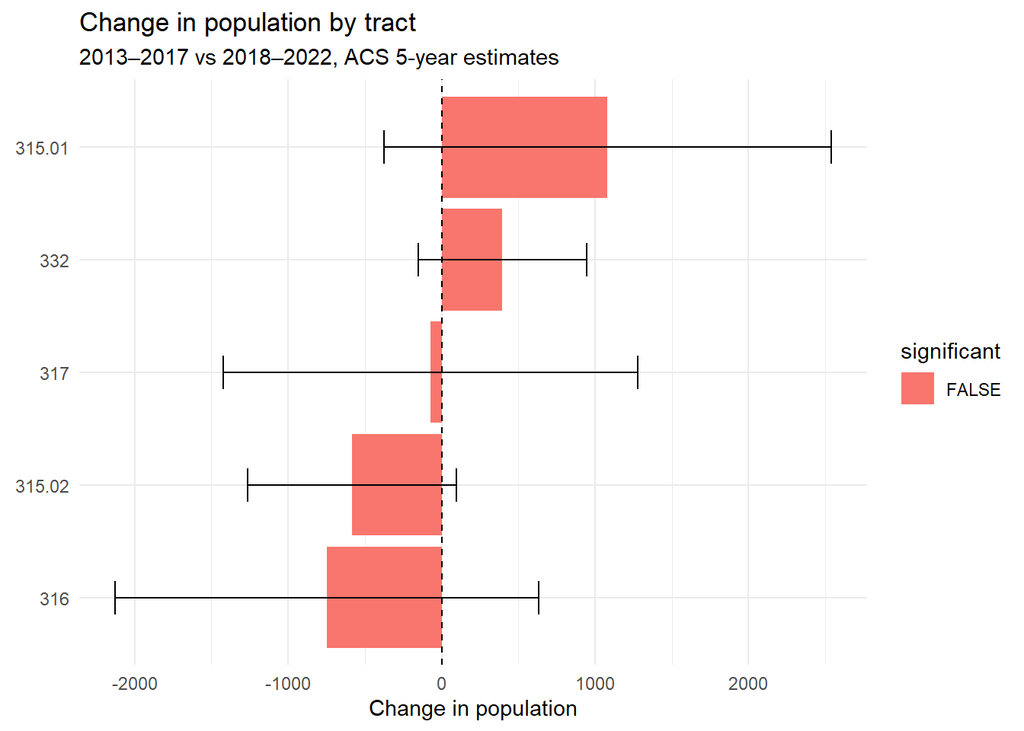

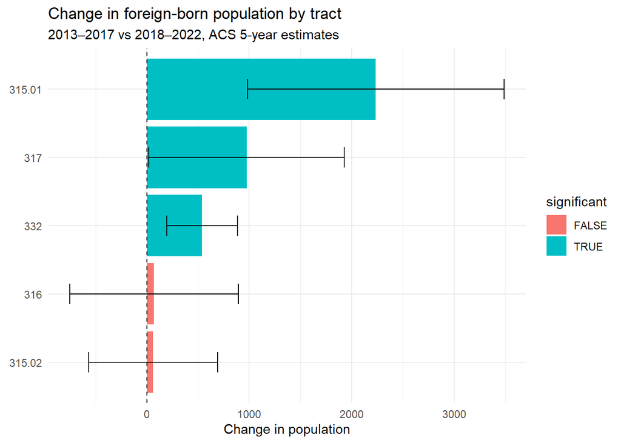

```r
MOE_sum_pop <- moe_sum(Mayfair_change$foreignM_17, Mayfair_change$foreignE_17)

MOE_sum_foreign <- moe_sum(Mayfair_change$foreignM_22, Mayfair_change$foreignE_22)

SE_diff <- sqrt(((933.0777^2)/1.645)+((1671.258^2)/1.645))

z_score <- (9028-5142)/SE_diff

Population_difference <- 9028-5142

Margin <- 1.645*SE_diff
```

Using the function moe_sum from tidycensus, we can get the margin of error for the foreign-born resident estimates at the neighborhood level, and thus calculate whether there was a difference in the estimates at a neighborhood level between 2017 and 2022. These calculations reveal that the difference in the foreign-born population at the neighborhood level between 2017 and 2022 is about 3,886 people, give or take 2,455. The z-score of 2.6 reveals that this difference is, at least, significant.

## Part 3 — Adjudicating

Sorting the article’s claims into three buckets produces the following results:

Supported: There was a significant increase in the immigrant population in the neighborhood of Mayfair between 2017 and 2022. Taking into account the margins of error for each estimate in this analysis reveals that the difference between the two years is unlikely to be zero, given the z-score and the range of the confidence interval of the difference.

Not supported: Mayfair’s population did not significantly increase between 2017 and 2022. Analyzing the difference in the population estimates between the two years did not produce significant z-scores for any of the tracts, signaling that the changes in population estimates are unlikely to be non-zero.

Cannot be determined: It is unclear whether Philadelphia’s population significantly increased between 2023 and 2024. The Census Bureau does not list margins of error for those county-wide population estimates in the 5-year ACS data, therefore I cannot conduct the same analysis for this claim as I did for Mayfair. This also means that I can’t verify how Mayfair’s demographic changes compare to Philadelphia’s.

## Part 4 — Rewriting the Claim

The neighborhood of Mayfair, in the 19149 ZIP code of Northeast Philadelphia, had about 26,601 residents in 2022. We can be moderately confident that about 34% of those residents were foreign-born. The immigrant population there grew by at least 1,431 people (about 28%) from 2013–2017 to 2018–2022, even though the neighborhood’s population on the whole did not significantly increase.

## Sources

“Immigration Leads Philadelphia’s Population Growth After Years of Decline.” Northeast Times, March 26, 2025. https://northeasttimes.com/2025/03/26/philadelphia-population/